# The Dogs of Zurich

## An exploratory analysis by Chris Newton

1. Introduction
2. Data Collection/Wrangling

A. Zurich Dog Ownership Data  
B. American Kennel Club Breed Information  
3. Exploratory Data Analysis  
A. Breed Popularity Over Time  
B. Breed Popularity by Age  
4. Hypothesis Testing 5. Conclusions

# 1. Introduction

They say you can tell a lot about a man by his dog. But just how much can we infer about a dog's owner by looking at aspects of their pet ownership? In this notebook we'll be exploring the predictive power of various attributes of dog ownership by answering the question: can you predict a dog owner's age given knowledge of their dog's breed, city district, or other fields?

# 2. Data Collection/Wrangling

## 2A. Zurich Dog Ownership Data

The initial dataset I'm using in this project is a record of dogs registered by their owners in Zurich, Switzerland up to 2017.

Downloaded from https://www.kaggle.com/datasets/kmader/dogs-of-zurich?select=20170308hundehalter.csv which was in turn taken from [Open Data Zurich](https://data.stadt-zuerich.ch/).

```python
import pandas as pd
import seaborn as sns
import matplotlib
import matplotlib.pyplot as plt
```

```python
dogs = pd.read_csv("zurich_dogs_2017.csv")
```

```python
dogs.head()
```

|  | HALTER_ID | ALTER | GESCHLECHT | STADTKREIS | STADTQUARTIER | RASSE1 | RASSE1_MISCHLING | RASSE2 | RASSE2_MISCHLING | RASSENTYP | GEBURTSJAHR_HUND | GESCHLECHT_HUND | HUNDEFARBE |
| --- | --- | --- | --- | --- | --- | --- | --- | --- | --- | --- | --- | --- | --- |
| 0 | 126 | 61-70 | m | 9.0 | 92.0 | Welsh Terrier | NaN | NaN | NaN | K | 2011 | w | schwarz/braun |
| 1 | 171 | 61-70 | m | 3.0 | 31.0 | Berner Sennenhund | NaN | NaN | NaN | I | 2009 | m | tricolor |
| 2 | 574 | 61-70 | w | 2.0 | 23.0 | Mischling gross | NaN | NaN | NaN | I | 2013 | w | schwarz |
| 3 | 695 | 41-50 | m | 6.0 | 63.0 | Labrador Retriever | NaN | NaN | NaN | I | 2012 | w | braun |
| 4 | 893 | 61-70 | w | 7.0 | 71.0 | Mittelschnauzer | NaN | NaN | NaN | I | 2010 | w | schwarz |

The immediate issue is that I don't speak German, so we'll first have to do a bit of translation. The column name translation scheme is:

German English New Column Name  
ALTER -> age -> human_age_range  
GESCHLECHT -> gender -> human_gender  
STADTKREIS -> city district -> district  
RASSE1 -> primary breed -> breed1  
RASSE1_MISCHLING -> hybrid -> hybrid  
RASSE2 -> secondary breed -> breed2  
GEBURTSJAHR_HUND -> dog birth year -> dog_year  
GESCHLECHT_HUND -> dog gender -> dog_gender  
HUNDEFARBE -> dog color -> dog_color

Before we translate the column names, we'll remove the columns we don't care about/can't derive meaning from. (1) HALTER_ID is some kind of person ID used in the Swiss government, but doesn't mean much for our purposes. (2) STADTQUARTIER is a more specific location identifier than district, but district is enough location classification for us. (3) RASSE2_MISCHLING has no values. (4) RASSENTYP is some unclear classification of dog breed, but since we already have detailed breed and hyrid(mix) information, we won't worry about it. We'll drop these four columns:

```python
dogs = dogs.drop(['HALTER_ID', 'STADTQUARTIER', 'RASSE2_MISCHLING', 'RASSENTYP'], axis=1)
```

Now we translate the column names:

```python
dogs.columns = ['human_age_range', 'human_gender', 'district', 'breed1', 'hybrid', 'breed2', 'dog_year', 'dog_gender', 'dog_color']
dogs.head()
```

|  | human_age_range | human_gender | district | breed1 | hybrid | breed2 | dog_year | dog_gender | dog_color |
| --- | --- | --- | --- | --- | --- | --- | --- | --- | --- |
| 0 | 61-70 | m | 9.0 | Welsh Terrier | NaN | NaN | 2011 | w | schwarz/braun |
| 1 | 61-70 | m | 3.0 | Berner Sennenhund | NaN | NaN | 2009 | m | tricolor |
| 2 | 61-70 | w | 2.0 | Mischling gross | NaN | NaN | 2013 | w | schwarz |
| 3 | 41-50 | m | 6.0 | Labrador Retriever | NaN | NaN | 2012 | w | braun |
| 4 | 61-70 | w | 7.0 | Mittelschnauzer | NaN | NaN | 2010 | w | schwarz |

Another translation that needs to be done is within the values for breed1 and breed2. Some values such as 'mop' in breed1 are German versions of breed names. For reasons that will be explained during part 3 (exploratory analysis), we won't worry about translating all of the unique breed values. We'll just translate some of the most popular breed names (we determine popularity later), as these will be the focus of our investigations:

Mischling klein -> small mix  
Mischling gross -> large mix  
Französische Bulldogge -> French bulldog  
Mops -> pug

```python
dogs['breed1'].replace('Mischling klein', 'Small Mix', inplace=True)
dogs['breed1'].replace('Mischling gross', 'Large Mix', inplace=True)
dogs['breed1'].replace('Französische Bulldogge', 'French Bulldog', inplace=True)
dogs['breed1'].replace('Mops', 'Pug', inplace=True)
```

Translation accuracy wasn't an issue because column names were simple and descriptive in their original German, and also simple German words just tend to translate well using google translate. For extra security, iffy translations were ran by my German-speaking roommate.

```python
dogs['hybrid'].unique()
```

```
array([nan, 'Mischling'], dtype=object)
```

An indiosyncracy in the data is that the hybrid column has the string 'Mischling' to mean true and NaN to mena false. It would be prettier if these were replaced with python booleans. Let's do that:

```python
dogs['hybrid'].replace('Mischling', True, inplace=True)
dogs['hybrid'].replace(float('nan'), False, inplace=True)
```

```python
len(dogs['breed1'].unique())
```

```
304
```

```python
dogs[dogs['hybrid'] == True]['breed2'].unique()
```

```
array([nan], dtype=object)
```

Later on we'll want to do numerical analysis on owner ages, so we should have a column quantifying owner age. The dataset gives us age ranges, which we'll use to make a column of average age.

```python
dogs['human_age_range'].unique()
```

```
array(['61-70', '41-50', '51-60', '71-80', '81-90', '31-40', '91-100',
       '21-30', nan, '11-20'], dtype=object)
```

There are 9 age ranges, each of 10 years. Convert to average of min and max age in range.

```python
# make new column for avg age
dogs['human_avg_age'] = dogs['human_age_range']
dogs['human_avg_age'] = dogs['human_avg_age'].replace(
                                    ['11-20', '21-30', '31-40', '41-50', '51-60', '61-70', '71-80', '81-90', '91-100'],
                                    [15.5, 25.5, 35.5, 45.5, 55.5, 65.5, 75.5, 85.5, 95.5])
dogs['human_avg_age'].unique()
```

```
array([65.5, 45.5, 55.5, 75.5, 85.5, 35.5, 95.5, 25.5,  nan, 15.5])
```

But we don't want those stray nan values, they will mess with our code later. We'll just drop those rows, there aren't very many of them anyway.

```python
# remove rows with nan in human_avg_age column
dogs = dogs[dogs['human_avg_age'].notnull()]
dogs['human_avg_age'].unique()
```

```
array([65.5, 45.5, 55.5, 75.5, 85.5, 35.5, 95.5, 25.5, 15.5])
```

As a final note, you might have noticed that our dataset consists of only nominal(categorical) data attributes: discrete age ranges, districts, breed names, and so on. How can we do data science on this set of qualitative attributes? We'll quantify some of these categorical data points into quantitative data. For example, we may want to look into breed popularity trends over time. We can quantify a specific breed's popularity over time by counting the number of births of that breed for each year. In this way, the relative prevalence of qualitative data in our dataset IS quantitative data.

```python
dogs.head()
```

|  | human_age_range | human_gender | district | breed1 | hybrid | breed2 | dog_year | dog_gender | dog_color | human_avg_age |
| --- | --- | --- | --- | --- | --- | --- | --- | --- | --- | --- |
| 0 | 61-70 | m | 9.0 | Welsh Terrier | False | NaN | 2011 | w | schwarz/braun | 65.5 |
| 1 | 61-70 | m | 3.0 | Berner Sennenhund | False | NaN | 2009 | m | tricolor | 65.5 |
| 2 | 61-70 | w | 2.0 | Large Mix | False | NaN | 2013 | w | schwarz | 65.5 |
| 3 | 41-50 | m | 6.0 | Labrador Retriever | False | NaN | 2012 | w | braun | 45.5 |
| 4 | 61-70 | w | 7.0 | Mittelschnauzer | False | NaN | 2010 | w | schwarz | 65.5 |

## 2B. American Kennel Club Breed Information

The zurich data gives us the mapping from dog breed to owner age, but lacks quantitative statistics about breeds that we need to hypothesis test. This AKC dataset contains specific attributes like weight, height, and temperament that we could use to make better age predictions down the line. There are 277 breeds.

AKC dog breed attribute data from https://tmfilho.github.io/akcdata/

```python
akc = pd.read_csv("akc-data-latest.csv")
akc.columns
```

```
Index(['Unnamed: 0', 'description', 'temperament', 'popularity', 'min_height',
       'max_height', 'min_weight', 'max_weight', 'min_expectancy',
       'max_expectancy', 'group', 'grooming_frequency_value',
       'grooming_frequency_category', 'shedding_value', 'shedding_category',
       'energy_level_value', 'energy_level_category', 'trainability_value',
       'trainability_category', 'demeanor_value', 'demeanor_category'],
      dtype='object')
```

'Unnamed: 0' contains the breed name. Temperament, height info, weight info, and energy level sound like the salient predictive factors for owner age. Let's look at those columns:

```python
akc[['temperament', 'min_height', 'max_height', 'min_weight', 'max_weight', 'energy_level_value']].head()
```

|  | temperament | min_height | max_height | min_weight | max_weight | energy_level_value |
| --- | --- | --- | --- | --- | --- | --- |
| 0 | Confident, Famously Funny, Fearless | 22.86 | 29.21 | 3.175147 | 4.535924 | 0.6 |
| 1 | Dignified, Profoundly Loyal, Aristocratic | 63.50 | 68.58 | 22.679619 | 27.215542 | 0.8 |
| 2 | Friendly, Clever, Courageous | 58.42 | 58.42 | 22.679619 | 31.751466 | 0.6 |
| 3 | Courageous, Dignified, Profoundly Loyal | 60.96 | 71.12 | 31.751466 | 58.967008 | 0.8 |
| 4 | Affectionate, Loyal, Playful | 58.42 | 63.50 | 34.019428 | 38.555351 | 0.8 |

Temperament appears to be too complex to use as a predictor, we wanted quantitative attributes anyway so we'll drop that.

```python
akc = akc[['Unnamed: 0', 'min_height', 'max_height', 'min_weight', 'max_weight', 'energy_level_value']]
## rename 'unnamed: 0' to breed
akc.rename(columns={'Unnamed: 0':'breed'}, inplace=True)
```

The task now is to merge this data into our main dataset (dogs) such that entries in dogs have additional columns for height, weight, and energy_level. In order to associate our akc attributes with each entry, we need to match breed names from one to the other. The problem is that some of our breed names in the dogs dataframe are in German whereas akc is in english. My initial plan was to use python's translate package to help with this, but it limits daily translations to some number less than 304 (the number of unique breed names in our main dataset dogs. On top of this, many of the translations would be inexact to the breed names in AKC, so an automated solution is farfetched with my resources. So I made the decision to manually translate the german breed names in dogs to the matching breed names in akc. Translating all 304 breeds by hand would be miserable and for my purposes, I won't need all the data, especially considering that the vast majority of samples fit in a small subset of breed names. So I'll translate the top 40 breeds and use only this subset of the data for the rest of the project.

We'll make a count of each breed, which we'll then use to sort breeds by count, allowing us to see the top 40 breeds.

```python
## make a dict breed1_counts where breed1_counts['<breed>'] is the number of occurances of <breed> in breed1
## initialize each entry (i.e breed) in breed1_counts to 0
breed1_counts = dict((breed,0) for breed in dogs['breed1'].unique())

## count breeds row by row
for index, row in dogs.iterrows():
    breed1_counts[row['breed1']] += 1

## check number of dogs counted == number of dogs in original dataset
print(sum(breed1_counts.values()))

## sort our breeds by count:
breed1_counts = dict(sorted(breed1_counts.items(), key=lambda item: item[1], reverse=True))
```

```
7154
```

```python
## see how many dogs in the top 40
sum(list(breed1_counts.values())[:40])
```

```
5116
```

```python
# dogs dataframe - get top 53 breed names
top53 = list(breed1_counts.keys())[:53]
dogs_top53 = dogs[dogs['breed1'].isin(top53)]
```

```python
## translate and replace german values with matching values from AKC dataset
dogs_top40 = dogs_top53.replace(
    ['Malteser', 'Pudel', 'Zwergspitz', 'Zwergpudel',  'Berner Sennenhund',  'Deutscher Schäfer', 'Pinscher', 'Havaneser',
    'Appenzeller', 'Flat Coated Retriever', 'Tibet Terrier', 'Bergamasker', 'Zwergschnauzer', 'Foxterrier',
    'Englische Bulldogge', 'Parson Jack Russell Terrier'],
    ['Maltese', 'Poodle (Standard)', 'Pomeranian', 'Poodle (Miniature)', 'Bernese Mountain Dog', 'German Shepherd Dog',
    'German Pinscher', 'Havanese', 'Appenzeller Sennenhund', 'Flat-Coated Retriever', 'Tibetan Terrier', 'Bergamasco Sheepdog',
    'Miniature Schnauzer', 'English Foxhound', 'Bulldog', 'Parson Russell Terrier'])

dogs_top40.drop(dogs_top40[dogs_top40['breed1'] == 'Small Mix'].index, inplace = True)
dogs_top40.drop(dogs_top40[dogs_top40['breed1'] == 'Jack Russel Terrier'].index, inplace = True)
dogs_top40.drop(dogs_top40[dogs_top40['breed1'] == 'Large Mix'].index, inplace = True)
dogs_top40.drop(dogs_top40[dogs_top40['breed1'] == 'Bolonka Zwetna'].index, inplace = True)
dogs_top40.drop(dogs_top40[dogs_top40['breed1'] == 'Schäfer'].index, inplace = True)
dogs_top40.drop(dogs_top40[dogs_top40['breed1'] == 'Zwergpinscher'].index, inplace = True)
dogs_top40.drop(dogs_top40[dogs_top40['breed1'] == 'Terrier'].index, inplace = True)
dogs_top40.drop(dogs_top40[dogs_top40['breed1'] == 'Dackel'].index, inplace = True)
dogs_top40.drop(dogs_top40[dogs_top40['breed1'] == 'Podenco'].index, inplace = True)
dogs_top40.drop(dogs_top40[dogs_top40['breed1'] == 'Rauhaar Dackel'].index, inplace = True)
dogs_top40.drop(dogs_top40[dogs_top40['breed1'] == 'Spitz'].index, inplace = True)
dogs_top40.drop(dogs_top40[dogs_top40['breed1'] == 'Continental Bulldog'].index, inplace = True)
dogs_top40.drop(dogs_top40[dogs_top40['breed1'] == 'Husky'].index, inplace = True)
len(dogs_top40)
```

```
3897
```

Note that after cleaning the data of breeds not in the AKC dataset, we have 3897 entries, which is still more than enough.

The AKC dataset had no matching breed for small mix, jack russel terrier, large mix, bolonka, schafer, zwergpinscher, terrier, dackel, podenco, Rauhaar Dackel, spitz, continental bulldog, and husky. That makes 13 breeds we have to throw out, so we need the top 53 to get our desired top 40 breeds. The last step is to merge the height, weight, and energy level from akc to dogs_top40. I set height and weight to be the average of their min and max values.

```python
## merge wegith, height, and energy_level columns into main df
top40 = dogs_top40['breed1'].unique()
dogs_top40['weight'] = 0
dogs_top40['height'] = 0
dogs_top40['energy_level'] = 0
for breed in top40:
    akc_entry = akc[akc['breed'] == breed]
    dogs_top40.loc[dogs_top40['breed1'] == breed, 'weight'] = \
                                            (akc_entry['min_weight'].values[0] + akc_entry['max_weight'].values[0]) / 2
    dogs_top40.loc[dogs_top40['breed1'] == breed, 'height'] = \
                                            (akc_entry['min_height'].values[0] + akc_entry['max_height'].values[0]) / 2
    dogs_top40.loc[dogs_top40['breed1'] == breed, 'energy_level'] = akc_entry['energy_level_value'].values[0]
dogs_top40.head()
```

|  | human_age_range | human_gender | district | breed1 | hybrid | breed2 | dog_year | dog_gender | dog_color | human_avg_age | weight | height | energy_level |
| --- | --- | --- | --- | --- | --- | --- | --- | --- | --- | --- | --- | --- | --- |
| 1 | 61-70 | m | 3.0 | Bernese Mountain Dog | False | NaN | 2009 | m | tricolor | 65.5 | 41.957294 | 64.135 | 0.8 |
| 3 | 41-50 | m | 6.0 | Labrador Retriever | False | NaN | 2012 | w | braun | 45.5 | 30.617485 | 58.420 | 1.0 |
| 5 | 51-60 | m | 10.0 | Shih Tzu | False | NaN | 2011 | m | schwarz/weiss | 55.5 | 5.669905 | 24.765 | 0.6 |
| 8 | 51-60 | w | 11.0 | Lagotto Romagnolo | False | NaN | 2016 | w | weiss/beige | 55.5 | 13.380975 | 44.450 | 0.6 |
| 10 | 71-80 | w | 8.0 | Havanese | False | NaN | 2016 | w | hellbraun/weiss | 75.5 | 4.535924 | 25.400 | 0.6 |

There are also nan values in energy_level. Drop those rows.

```python
print(f"Before: {len(dogs_top40.index)}")
dogs_top40 = dogs_top40[dogs_top40['energy_level'].notnull()]
print(f"After: {len(dogs_top40.index)}")
```

```
Before: 3897
After: 3823
```

And finally our dataset is ready.

# 3. Exploratory Data Analysis

## 3A. Breed Popularity Over Time

Let's visualize breed popularity over time for the most popular breeds. As discussed earlier, we have 304 unique dog breeds, which would make too many seperate classes to visualize. First we'll have to figure out which dog breeds are popular:

```python
## print the 50 most prevalent breeds
## str casting to remove newline so we can print compactly (I know it's ugly)
print(str(dict(list(breed1_counts.items())[:50])).replace("\n", ""))
## print count of dogs in top 50
print("\n", sum(list(breed1_counts.values())[:50]))
```

[output not shown]

Now we know the 50 most popular breeds over our entire time interval. 50 is still too many for visualization, I just printed these to illustrate the how the distribution drops off after a certain point. For exploration, there is a marked drop-off of counts after the top 10, so start by focus just on the top 10. It is important to note that the value of k we pick for analysis of the top k breeds ultimately comes down to choice and convenience of visualization. The 10 most popular breeds in order are:

```python
top10 = list(dict(list(breed1_counts.items())[:10]).keys())
print(top10)
```

```
['Small Mix', 'Chihuahua', 'Labrador Retriever', 'Yorkshire Terrier', 'Jack Russel Terrier', 'French Bulldog', 'Large Mix', 'Malteser', 'Pug', 'Golden Retriever']
```

Now we can plot the change in popularity of these 10 breeds over time:

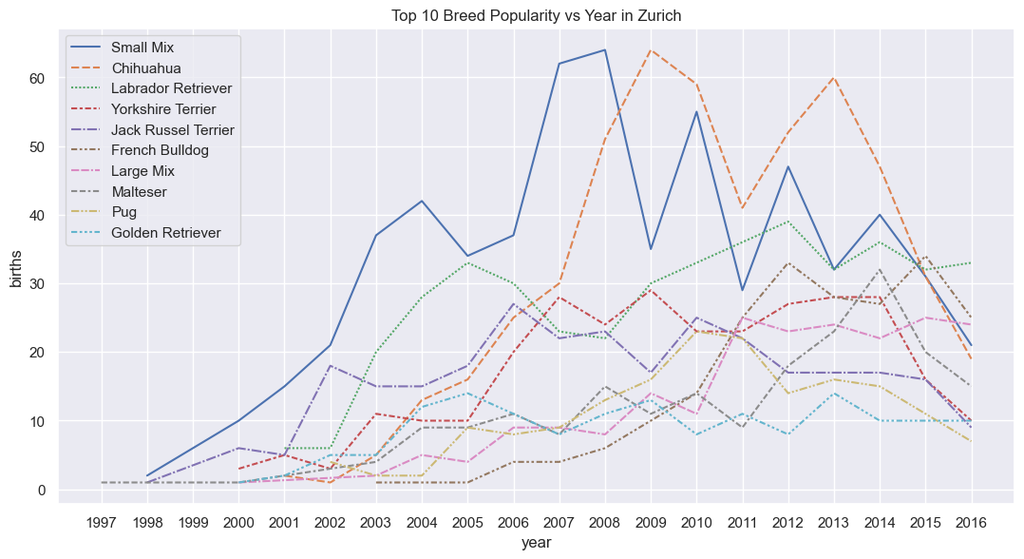

```python
## Top 10 breed popularity over time

## Build a dataframe: columns are breed count, rows are each year
top10_per_year = pd.DataFrame(index=[i for i in range(1997,2017)])

for breed in top10:
    breed_df = dogs[dogs['breed1'] == breed]
    breed_per_year = pd.Series(index=sorted(breed_df['dog_year'].unique()), data=0)

    for index, row in breed_df.iterrows():
        breed_per_year[row['dog_year']] += 1
    top10_per_year[breed] = breed_per_year

sns.set(rc={'figure.figsize':(13,6.5)})
lp = sns.lineplot(data=top10_per_year)
lp.set(title='Top 10 Breed Popularity vs Year in Zurich', xlabel='year', ylabel='births')
lp.set_xticks([i for i in range(1997,2017)])
```

## 3B. Breed Popularity by Age

Say your middle-aged parents are moving to Zurich. They are also in the market for a dog, but they want a breed that will be a good fit for their lifestyle. We might want to see what breeds are popular with people their age. Dogs that are owned by mostly younger people may be too rowdy or require too much activity for them. In this section we ask: what is the relationship between age range and breed preference?

To get a general idea of how age affects breed choice, we could start by looking at the average age of the owners of the top 10 breeds. We'll make a violin plot illustrating the distribution of ages for each of the top 10 breeds:

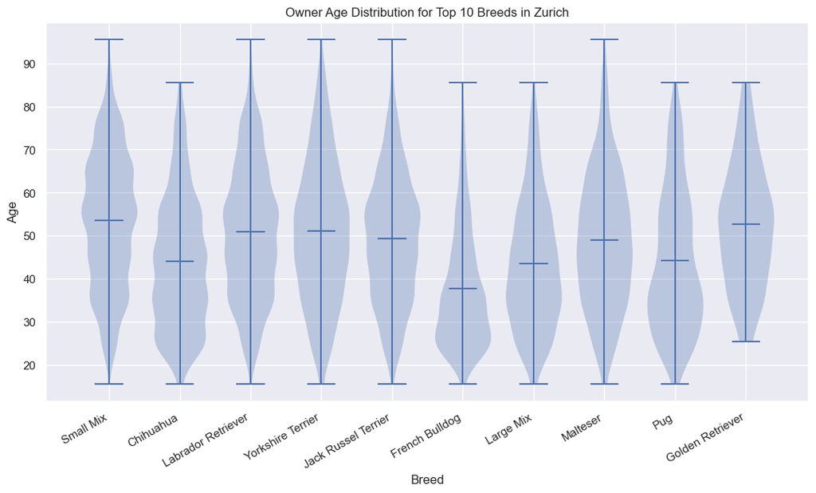

```python
# aggregate age data for each of the top 10 breeds
age_dist_per_breed = []
for breed in top10:
    breed = dogs[dogs['breed1'] == breed]
    age_dist_per_breed.append(breed['human_avg_age'])

fig, ax = plt.subplots()
t = [i for i in range(10)]

# make violinplot with each category corresponding to a breed
ax.violinplot(age_dist_per_breed,t,widths=0.8,showmeans=True)
ax.set_xticks(ticks = t, labels = top10)
ax.set_xlabel("Breed")
ax.set_ylabel("Age")
ax.set_title("Owner Age Distribution for Top 10 Breeds in Zurich")
plt.setp(ax.get_xticklabels(), rotation=30, horizontalalignment='right')
fig.savefig("violin_raw_data.png")
```

Code for slanted xlabels courtesy of [8one6](https://stackoverflow.com/questions/26700598/matplotlib-showing-x-tick-labels-overlapping) on stackoverflow.

It turns out that from this relationship we can't pick out a clear pattern of breed preference vs breed size. Small mixes had the oldest mean owner age, but Golden retrievers had the second oldest. Some small dogs are especially popular with a younger population. The french bulldog has by far the lowest average owner age, and further, the breed's violin plot shows that the majority of french bulldog owners are younger than the mean (roughly 38). They must be very trendy in Zurich. By comparison of means, we could say a middle aged or older person would be most satisfied with a small mix, Labrador Retriever, Yorkshire Terrier, or Golder Retriever. If we also consider the distribution about the means (the "swell" of the violins), we'll notice that small mixes and jack russels have distributions that are slightly skewed left, meaning a majority of their owners are older than their mean owner ages (53 and 50 respectively). This points to small mixes and jack russels as especially popular amongst the older generation.

A ridge plot visualizing the same relationship:

[figure not shown]

```python
# get dataframe of only top10 breeds
dogs_top10 = dogs[dogs['breed1'].isin(top10)]

# make range plot
sns.set_theme(style="white", rc={"axes.facecolor": (0, 0, 0, 0), 'axes.linewidth':2})
palette = sns.color_palette("hls", 10)

g = sns.FacetGrid(dogs_top10, palette=palette, row="breed1", hue="breed1", aspect=11, height=0.9)
g.map_dataframe(sns.kdeplot, x="human_avg_age", fill=True, alpha=1)
g.map_dataframe(sns.kdeplot, x="human_avg_age", color='black')
def label(x, color, label):
    ax = plt.gca()
    ax.text(0, .2, label, color='black', fontsize=13,
            ha="left", va="center", transform=ax.transAxes)

g.map(label, "breed1")
g.fig.subplots_adjust(hspace=-.6)
g.set_titles("")
g.set(yticks=[], xlabel="IMDB Score")
g.despine( left=True)
plt.suptitle('Age Ranges of Top 10 Most Popular Breeds', y=0.98)
```

Most of the above code is courtesy of [Thiago Carvalho](https://python.plainenglish.io/ridge-plots-with-pythons-seaborn-4de5725881af).

This plot style illustrates the shape of each distribution. The trendiness of french bulldogs and pugs with the younger generations is more obvious this way. Look at those rightward skews! This exploration has shown that there is some correlation between breed and owner age. This will be the primary attribute we'll use for age classification.

# 4. Hypothesis Testing

I believe there is a relationship between dog size and owner age, where as dog size increases, owner age decreases. I decided to use weight as the metric for dog size. We'll fit a linear regression to quantify the strength of this relationship.

null hypothesis: no relationship between dog weight and owner age  
alternative hypothesis: as dog weight increases, owner age decreases

```python
from sklearn import linear_model

x = [[x] for x in dogs_top40['weight'].values]
y = [[y] for y in dogs_top40['human_avg_age'].values]
model = linear_model.LinearRegression()
model = model.fit(x, y)
model.score(x, y)
print(f" Coefficient of determination: {model.score(x,y)} \n m: {model.coef_[0][0]} \n b: {model.intercept_[0]}")
```

```
 Coefficient of determination: 0.0116748661584688
 m: 0.15219121644706396
 b: 47.26692813353435
```

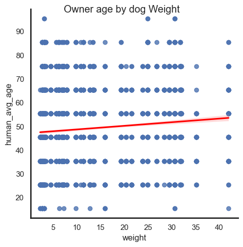

```python
sns.lmplot(x='weight', y='human_avg_age',data=dogs_top40, fit_reg=True,
           line_kws={'color': 'red'}).fig.suptitle("Owner age by dog Weight")
```

What about owner age vs the dog's energy level? You'd expect older folks to go for more easygoing dogs, but after the result of the previous test, I reevaluated my logic.

null hypothesis: no relationship between dog energy level and owner age  
alternate hypothesis: as energy level increases, age increases

```python
x = [[x] for x in dogs_top40['energy_level'].values]
y = [[y] for y in dogs_top40['human_avg_age'].values]

model = model.fit(x, y)
model.score(x, y)
print(f" Coefficient of determination: {model.score(x,y)} \n m: {model.coef_[0][0]} \n b: {model.intercept_[0]}")
```

```
 Coefficient of determination: 0.006564580695981981
 m: 6.775934822400637
 b: 44.66268731420884
```

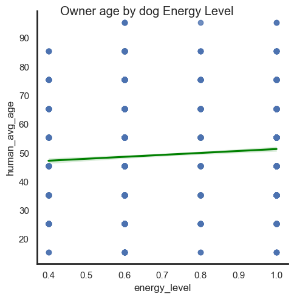

```python
sns.lmplot(x='energy_level', y='human_avg_age',data=dogs_top40, fit_reg=True,
           line_kws={'color': 'green'}).fig.suptitle("Owner age by dog Energy Level")
```

## Predicting Age: classify an owner's age using breed, district, year, etc

We'll attempt to classify an owner's age based on the quantifiable attributes of their dog ownership.

human_gender, breed1, dog_gender, and dog_color are all not numerical data, so we'll have to encode them for our model to make sense of. Human_gender and dog_gender resolve to either m or w (discussion of the gender binary is outside the scope of this class) so we can encode them as 0 and 1 respectively. breed1 and dog_color are more complex strings which I'll do a custom encoding of each.

Encoding dog_gender and human_gender:

```python
dogs = dogs_top40
for index, row in dogs.iterrows():
    if row['dog_gender'] == 'm':
        dogs.at[index, 'dog_gender'] = 0
    elif row['dog_gender'] == 'w':
        dogs.at[index, 'dog_gender'] = 1
for index, row in dogs.iterrows():
    if row['human_gender'] == 'm':
        dogs.at[index, 'human_gender'] = 0
    elif row['human_gender'] == 'w':
        dogs.at[index, 'human_gender'] = 1
```

Encoding breed1:

```python
dogs["breed1_enc"] = 0
encodings = {}
i = 0 # current encoding

# encode each breed in breed1 to integer in a new column in dogs
for index, row in dogs.iterrows():
    breed = row['breed1']
    if breed not in encodings.keys(): # if breed is not in encodings
        encodings[breed] = i # store encoding
        i += 1
    dogs.at[index, 'breed1_enc'] = encodings[breed]
```

Encoding dog_color:

```python
dogs["color_enc"] = 0
encodings = {}
i = 0 # current encoding

# encode each color in new column
for index, row in dogs.iterrows():
    color = row['dog_color']
    if color not in encodings.keys(): # if breed is not in encodings
        encodings[color] = i # store encoding
        i += 1
    dogs.at[index, 'color_enc'] = encodings[color]
```

```python
ages = dogs.pop('human_avg_age') # move human_avg_age to last column for convenience
dogs['human_avg_age'] = ages
```

```python
from sklearn.ensemble import RandomForestClassifier
from sklearn.model_selection import train_test_split, KFold, cross_validate
from sklearn import preprocessing, utils, datasets, tree, svm
from sklearn.metrics import accuracy_score
```